# Gene expression Deconvolution for human PDAC SRT datasets

Jia-Juan Tu

## Import library

```r
remove(list= ls())
library(ggplot2)
library(ggthemes)
library(scatterpie)
library(cowplot)
library(gridExtra)
library(viridis)
library(ggpubr)
library(rstatix)

library(RColorBrewer)

require(clusterProfiler)
require(org.Hs.eg.db)

require(dplyr)
library(stringr)
library(purrr)
library(stringr)

library(nichenetr)
library(tidyverse)
library(circlize)

library(tibble)


# Load necessary libraries
library(parallel)
library(doParallel)
library(glmnet)
```

### Load function

```r
source("./code/STged.R")
source("./code/benchmark.R")
source("./code/Module.R")
```

```r
qual_col_pals = brewer.pal.info[brewer.pal.info$category == 'qual',]
col_vector  <-  unlist(mapply(brewer.pal, qual_col_pals$maxcolors,
                              rownames(qual_col_pals)))
```

### load data

```r
datax = readRDS("./realdata/PDAC/PDACA_all.RDS")

stged = readRDS("./results/PDAC/model.est.rds")
```

```r
ctexp  = stged$F_list
beta.type = stged$beta
colnames(beta.type)
```

```
##  [1] "Acinar cells"              "Cancer clone A"
##  [3] "Cancer clone B"            "Ductal antigen presenting"
##  [5] "Ductal centroacinar"       "Ductal high hypoxic"
##  [7] "Ductal terminal"           "Endocrine cells"
##  [9] "Endothelial cells"         "Fibroblasts"
## [11] "Macrophages A"             "Macrophages B"
## [13] "Mast cells"                "mDCs A"
## [15] "mDCs B"                    "Monocytes"
## [17] "pDCs"                      "RBCs"
## [19] "T cells and NK cells"      "Tuft cells"
```

```r
cell_type = colnames(beta.type)
ind_spot =datax$spot_exp>0

ind = beta.type[,10]>0.05


st_exp_raw = ctexp[[10]]  #*ind_spot


colnames(st_exp_raw) = rownames(beta.type)

rownames(st_exp_raw)=  gsub("(^|[[:space:]])([[:alpha:]])", "\\1\\U\\2",
                            tolower(rownames(st_exp_raw )), perl = TRUE)

spot_loc_raw  = datax$spot_loc[rownames(beta.type) ,1:2]
spot_loc_raw$x = as.numeric(spot_loc_raw$x)
spot_loc_raw$y = as.numeric(spot_loc_raw$y)

spot_loc = spot_loc_raw[ind,]
```

```r
col_df <- data.frame(cell_types = c(cell_type,"Others"),
                     col_vector = c(col_vector[1:length(cell_type)],"gray"))
```

##get the estimated data

```r
beta = beta.type[ind ,]

cell_type = colnames(beta)

target  = j = cell_type[10]
target
```

```
## [1] "Fibroblasts"
```

# mHVG estimation analysis

## prepare the input

```r
st_exp  = st_exp_raw[,ind ]

dim(st_exp)
```

```
## [1] 9923  304
```

```r
Y_input = t(cleanCounts (st_exp, clean.only =TRUE) )

dim(Y_input)
```

```
## [1]  304 9923
```

```r
dim(beta)
```

```
## [1] 304  20
```

```r
neighbor =  colnames(beta)[colSums((beta!=0)*1)>(ncol(st_exp)*0.2)]

X_input = beta[,neighbor]
X_input = X_input[,-match(target, colnames(X_input))]
neighbor_sec = colnames(X_input)
neighbor_sec
```

```
## [1] "Acinar cells"         "Cancer clone A"       "Cancer clone B"
## [4] "Ductal centroacinar"  "Ductal terminal"      "Endothelial cells"
## [7] "mDCs B"               "T cells and NK cells" "Tuft cells"
```

```r
Y_scaled <- scale(Y_input)

file_path <- './results/PDAC/mHVG_elastic_est.RDS'

# Check if the file exists
if (!file.exists(file_path)) {
  # If the file doesn't exist, run the following code

  mHAG_est <- mHAG_func(X_scaled = X_input,
                        Y_scaled = Y_scaled,
                        alpha = 0.5,
                        num_cores = 10)

  # Save the result
  saveRDS(mHAG_est, file = file_path)
} else {
  # If the file exists, print a message
  mHAG_est = readRDS('./results/PDAC/mHVG_elastic_est.RDS')
}
```

```r
mHAG_res = mHAG_module(mHAG_est)

mHVG <- mHAG_res$mHVG

cat("number of mHVGs=",  length(mHVG), "\n")
```

```
## number of mHVGs= 915
```

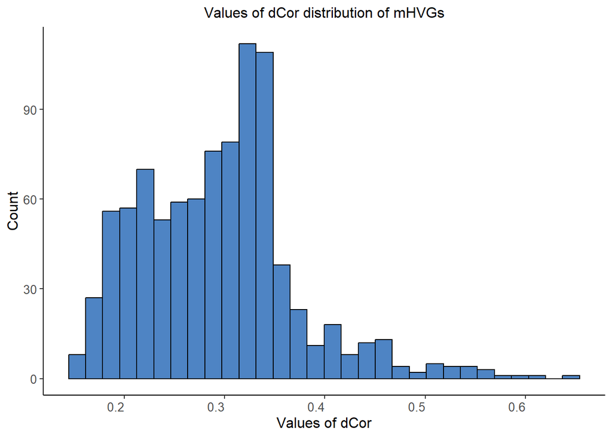

```r
result <- sapply(1:length(mHVG), function(i) {
  energy::dcor(Y_scaled[, mHVG[i]], X_input)
})


dcor.bar = ggplot(data = data.frame(x = result), aes(x = x)) +
    geom_histogram(fill = "#4E84C4", bins = 30, color = "black") +
    theme_bw() +
    labs(y = "Count", x = "Values of dCor",
         title = "Values of dCor distribution of mHVGs") +
    theme(
        axis.text.x.bottom = element_text(size = 10, hjust = 1),
        axis.text.y.left = element_text(size = 10),
        axis.title.x = element_text(size = 12, hjust = 0.5),
        axis.title.y = element_text(size = 12),
        plot.title = element_text(size = 12, hjust = 0.5),
        panel.grid.major = element_blank(),  # 移除主网格线
        panel.grid.minor = element_blank(),  # 移除次网格线
        panel.border = element_blank(),
        axis.line = element_line(colour = "black")
    )

print(dcor.bar)
```

## PCC score analysis

**NOTE**: PCC score for gene expression levels of fibroblast and neighbor cell type proportions on the ctHVGs

## ctHVG

```r
cat("number of mHVGs=",  length(mHAG_res$mHVG), "\n")
```

```
## number of mHVGs= 915
```

```r
cat("number of ctHVGs", "\n")
```

```
## number of ctHVGs
```

```r
apply(mHAG_res$ctHVG,2,sum, na.rm = TRUE)
```

```
##         Acinar cells       Cancer clone A       Cancer clone B
##                  480                  330                  143
##  Ductal centroacinar      Ductal terminal    Endothelial cells
##                  431                  254                  287
##               mDCs B T cells and NK cells           Tuft cells
##                  441                  138                  130
```

```r
ctHVG = mHAG_res$ctHVG
coeff = mHAG_res$coeff
```

## Calculate Joint score

```r
Joinscores = PCC.score(spot_exp = Y_input, coeff = mHAG_res$coeff, spot_prop = beta)
```

### plot barplot of joint scores

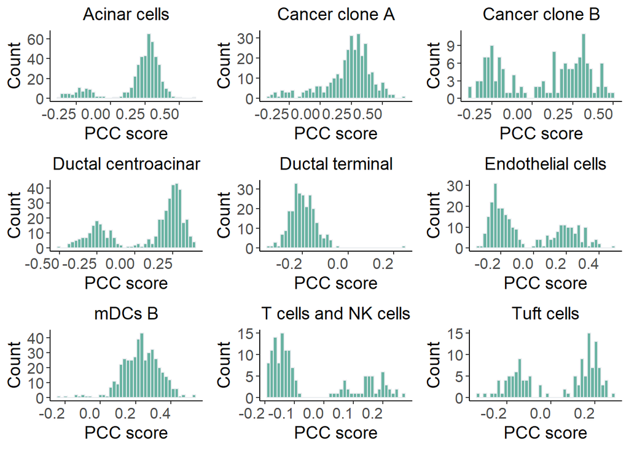

```r
score.barplot = Jointscore.barplot(Score = Joinscores, y.title="Count",
                                   x.title="PCC score",
                                   plot = FALSE, nrow = 1, fill="#69b3a2", color="#e9ecef")

pfig = cowplot::plot_grid(plotlist = score.barplot, ncol = 3)


pfig
```

## The number of ctHVGs

```r
clonea   = rownames(ctHVG)[ctHVG[,2]]
length(clonea)
```

```
## [1] 330
```

```r
cloneb   = rownames(ctHVG)[ctHVG[,3]]
length(cloneb)
```

```
## [1] 143
```

```r
i =2
colnames(coeff)[i]
```

```
## [1] "Cancer clone A"
```

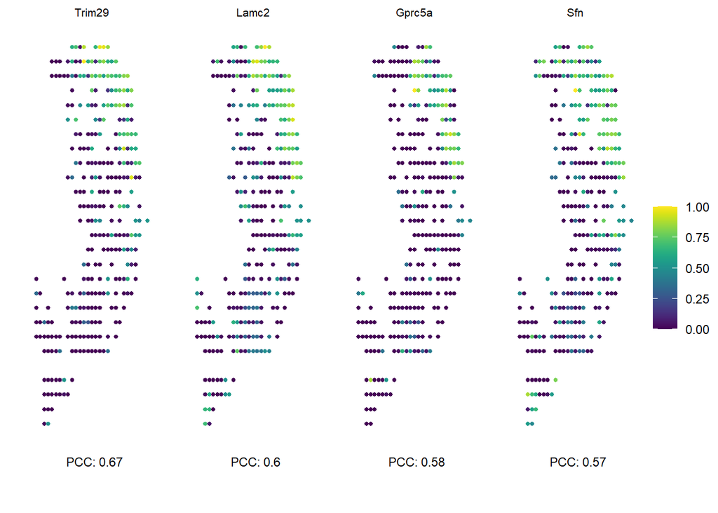

```r
plot1 = pval.srt.dot ( spot_exp = t(Y_input),  spot_prop = beta[,10],
                       spot_loc = spot_loc,
                        jointpcc = Joinscores[[i]], size =1, seck = 4)



psvgpor_clonea = ggpubr::ggarrange( plotlist = plot1, nrow = 1, ncol = 4,
                             common.legend = TRUE, legend = "right")
psvgpor_clonea
```

```r
i =3
colnames(coeff)[i]
```

```
## [1] "Cancer clone B"
```

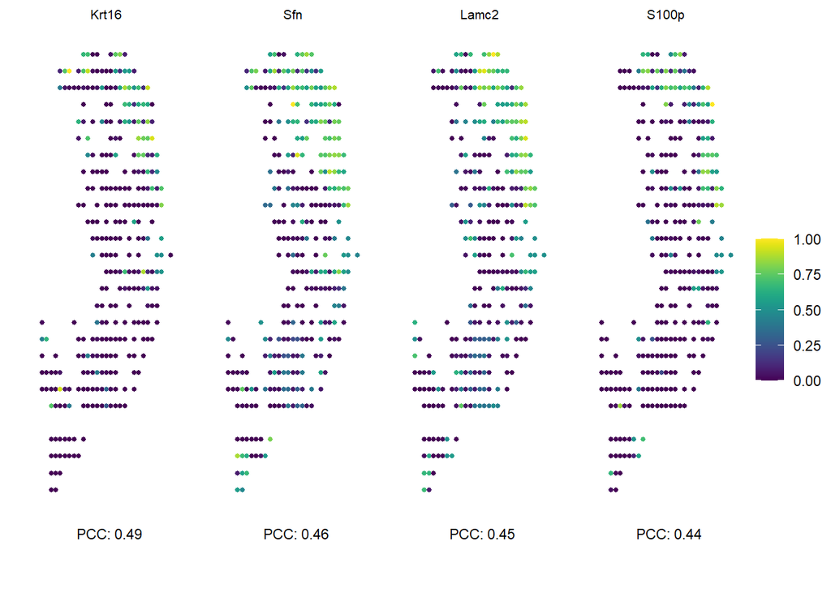

```r
plot2 = pval.srt.dot ( spot_exp = t(Y_input),  spot_prop = beta[,10],
                       spot_loc = spot_loc,
                        jointpcc = Joinscores[[i]], size =1, seck = 4)

psvgpor_cloneb = ggpubr::ggarrange( plotlist = plot2, nrow = 1, ncol = 4,
                             common.legend = TRUE, legend = "right")
psvgpor_cloneb
```

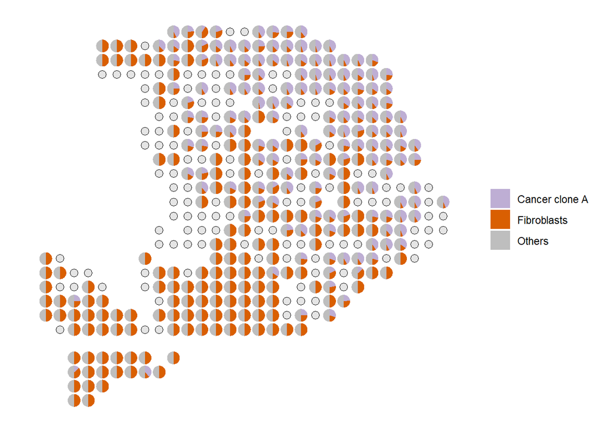

```r
proportion = beta.type
keep_spots <- rownames(proportion)[which(proportion[, "Fibroblasts"] > 0)]
sec_type  = c("Cancer clone A", "Fibroblasts")
test_proportion <- rowSums(proportion[keep_spots, sec_type])

prop_Sec <- cbind(proportion[keep_spots, sec_type], test_proportion)

colnames(prop_Sec) <- c(sec_type, "Others")
rownames(prop_Sec) <- keep_spots

pie_cthvg_clonea = plot_scatterpie(spot_loc_raw, prop_Sec, use_color = col_df  ,
                              pie_r = 0.8, circle_r = 0.7, point_size = 4)
pie_cthvg_clonea
```

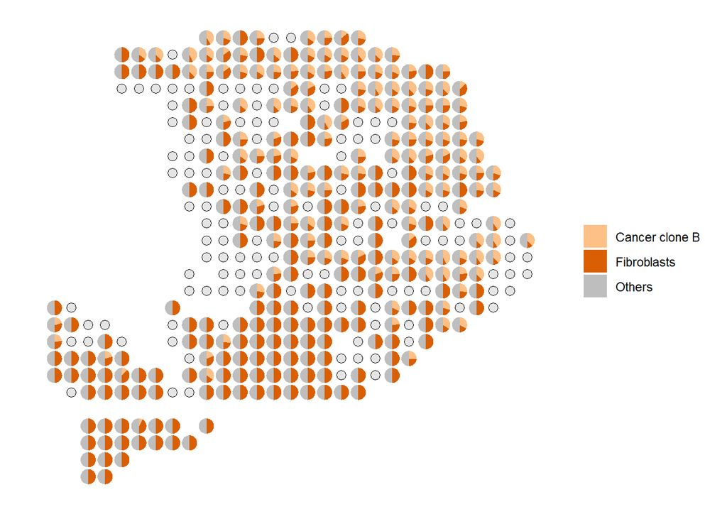

```r
### clone b
proportion = beta.type
keep_spots <- rownames(proportion)[which(proportion[, "Fibroblasts"] > 0)]
sec_type  = c("Cancer clone B", "Fibroblasts")
test_proportion <- rowSums(proportion[keep_spots, sec_type])

prop_Sec <- cbind(proportion[keep_spots, sec_type], test_proportion)

colnames(prop_Sec) <- c(sec_type, "Others")
rownames(prop_Sec) <- keep_spots

pie_cthvg_cloneb = plot_scatterpie(spot_loc_raw, prop_Sec, use_color = col_df  ,
                              pie_r = 0.8, circle_r = 0.7, point_size = 4)
pie_cthvg_cloneb
```

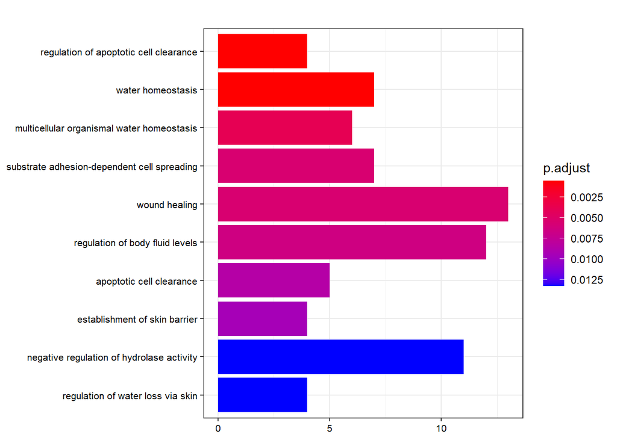

```r
ctGO_ana12 <-  enrichGO(gene =  toupper(cloneb),
                        OrgDb = org.Hs.eg.db,
                        keyType = "SYMBOL",
                        ont = "BP",
                        pAdjustMethod = "BH",
                        readable = TRUE)


barplot(ctGO_ana12 ,showCategory=10,font.size = 8,label_format = 50)
```

**Notes** We first define expressed genes in the cancer clone A or B cells (sender) and fibroblast cells (receiver). Genes are considered to be expressed within one cell type if their log2-transformed mean TPM (transcript per kilobase million) values are greater than 4, following the same criterion as in the NicheNet tutorial. The mean TPM value for each cell type is calculated based on the cell-type-specific gene expression of spots with the corresponding proportion greater than 0.05 within the focused spots.

```r
lr_network <- readRDS("./realdata/LR_analysis/lr_network_human_21122021.rds")

ligand_target_matrix <-  readRDS("./realdata/LR_analysis/ligand_target_matrix_nsga2r_final.rds")
```

**Notes:** Filtering Expressed Genes

```r
keep_genes <- rownames(stged$F_list$Fibroblasts)

keep_spots_clonea <- stged$beta[,"Cancer clone A"] > 0.05
keep_spots_cloneb <- stged$beta[,"Cancer clone B" ] > 0.05
keep_spots_fibro <- stged$beta[,"Fibroblasts"] > 0.05

# Identify expressed genes for T cells, macrophages, and malignant cells
expressed_genes_clonea <- keep_genes[log2(rowMeans(stged$F_list[["Cancer clone A"]][,keep_spots_clonea,
                                                                                     drop = FALSE] * 1e6) + 1) >= 4]

expressed_genes_cloneb<- keep_genes[log2(rowMeans(stged$F_list[["Cancer clone B"]][,keep_spots_cloneb, drop = FALSE] * 1e6) + 1) >= 4]

expressed_genes_fibro<- keep_genes[log2(rowMeans(stged$F_list[["Fibroblasts"]][,keep_spots_fibro, drop = FALSE] * 1e6) + 1) >= 4]
```

**Notes:**The gene set of interest comprises the identified potential interaction-changed genes, encompassing both significantly positively correlated genes and significantly negatively correlated genes.

```r
geneset_ctHVG_clonea <- intersect(convert_alias_to_symbols(toupper(clonea), "human", verbose = FALSE), colnames(ligand_target_matrix))

geneset_ctHVG_cloneb <- intersect(convert_alias_to_symbols(toupper(cloneb), "human", verbose = FALSE), colnames(ligand_target_matrix))
```

```r
test_genes <- rownames(stged$F_list$Fibroblasts)[rowSums(stged$F_list$Fibroblasts) != 0]

background_expressed_genes <- intersect(convert_alias_to_symbols(toupper(test_genes), "human", verbose = FALSE), rownames(ligand_target_matrix))
```

```r
# Identify ligands and receptors from the ligand-receptor network
ligands <- lr_network %>% pull(from) %>% unique()

expressed_ligands_clonea <- intersect(ligands, expressed_genes_clonea)
expressed_ligands_cloneb <- intersect(ligands, expressed_genes_cloneb)

receptors <- lr_network %>% pull(to) %>% unique()
expressed_receptors <- intersect(receptors, expressed_genes_fibro)

# Identify potential ligands interacting with receptors
potential_ligands_clonea <- lr_network %>% filter(from %in% expressed_ligands_clonea & to %in% expressed_receptors) %>% pull(from) %>% unique()

potential_ligands_cloneb <- lr_network %>% filter(from %in% expressed_ligands_cloneb & to %in% expressed_receptors) %>% pull(from) %>% unique()
```

**Notes:**We then perform NicheNet’s ligand activity analysis.

```r
# Predict ligand activities for cancer clone a
ligand_activities_clonea <- predict_ligand_activities(
  geneset = geneset_ctHVG_clonea,
  background_expressed_genes = background_expressed_genes,
  ligand_target_matrix = ligand_target_matrix,
  potential_ligands = potential_ligands_clonea
)

best_upstream_ligands_clonea <- ligand_activities_clonea %>% arrange(-aupr_corrected) %>% pull(test_ligand)

# Predict ligand activities forcancer clone b
ligand_activities_cloneb <- predict_ligand_activities(
  geneset = geneset_ctHVG_cloneb,
  background_expressed_genes = background_expressed_genes,
  ligand_target_matrix = ligand_target_matrix,
  potential_ligands = potential_ligands_cloneb
)

best_upstream_ligands_cloneb <- ligand_activities_cloneb %>% arrange(-aupr_corrected) %>% pull(test_ligand)
```

**Notes:**Assign specific ligands to cell types based on expression levels

```r
clonea_specific_ligands <- intersect(best_upstream_ligands_clonea, expressed_ligands_clonea)

cloneb_specific_ligands <- intersect(best_upstream_ligands_cloneb, expressed_ligands_cloneb)
```

**Notes:** When inferring target genes of the ligands, we consider the top 100 targets of at least one ligand according to the prior model.

```r
active_ligand_target_links_df_clonea <- best_upstream_ligands_clonea %>%
  lapply(get_weighted_ligand_target_links, geneset = geneset_ctHVG_clonea, ligand_target_matrix = ligand_target_matrix, n = 100) %>%
  bind_rows()

active_ligand_target_links_df_cloneb <- best_upstream_ligands_cloneb %>%
  lapply(get_weighted_ligand_target_links, geneset = geneset_ctHVG_cloneb, ligand_target_matrix = ligand_target_matrix, n = 100) %>%
  bind_rows()
```

**Notes:** clear data

**Notes:** clear data

```r
active_ligand_target_links_df_clonea_clear = na.omit(active_ligand_target_links_df_clonea)

active_ligand_target_links_df_cloneb_clear = na.omit(active_ligand_target_links_df_cloneb)
```

**Notes:** Create the Bubble Plot

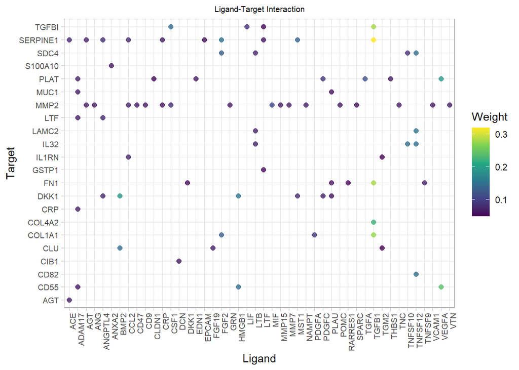

```r
# Convert the matrix to a data frame
df_clonea <- as.data.frame(active_ligand_target_links_df_clonea_clear)
colnames(df_clonea) <- c("Ligand", "Receptor", "Weight")
df_clonea$Weight <- as.numeric(df_clonea$Weight)
df_clonea = df_clonea[df_clonea$Weight>0.05,]


# Create the bubble plot
fig_clonea = ggplot(df_clonea, aes(x = Ligand, y = Receptor, size = Weight,color =Weight)) +
  geom_point(alpha = 0.8,size = 2) +
  scale_size_continuous(range = c(2, 15)) +
  theme_minimal() +  # Use a minimal theme for clarity
  labs(
    title = "Ligand-Target Interaction",
    x = "Ligand",
    y = "Target",
    size = "Interaction Weight"
  ) +theme_light() +
  theme(
    axis.text.x.bottom = element_text(size = 8,hjust = 1,angle = 90),
    axis.text.y.left = element_text(size = 8),
    #axis.title.x = element_blank(),
    # axis.title.y = element_blank(),
    plot.title = element_text( size=8,hjust = 0.5),
  )+  scale_color_viridis_c()

fig_clonea
```

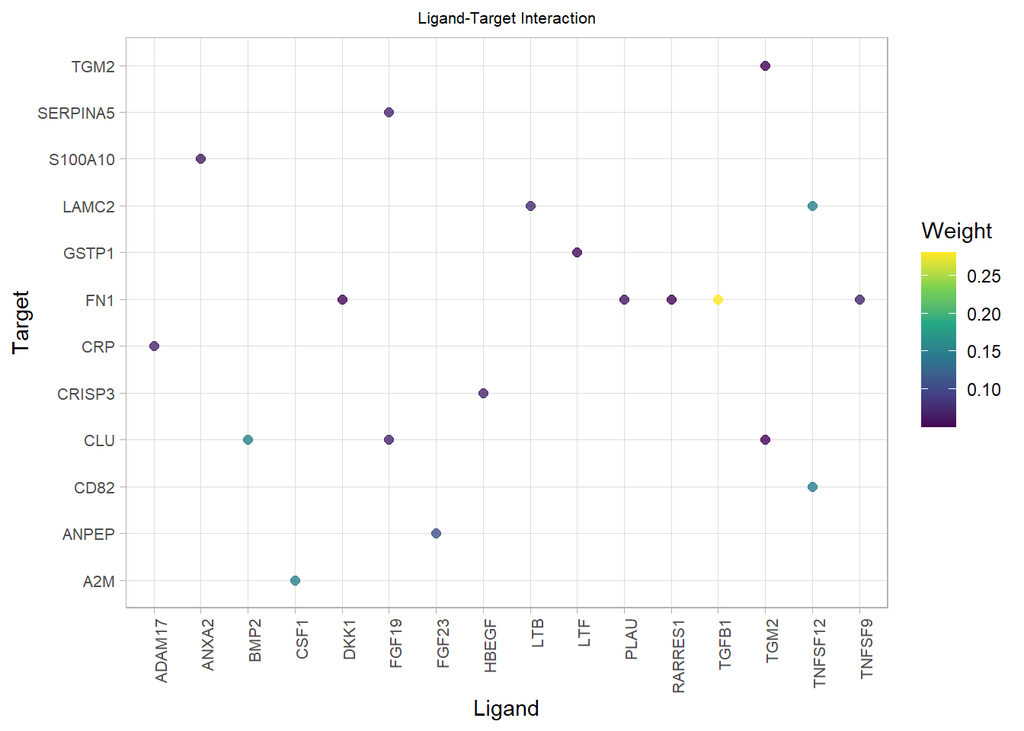

```r
# Convert the matrix to a data frame
df_cloneb <- as.data.frame(active_ligand_target_links_df_cloneb_clear)
colnames(df_cloneb) <- c("Ligand", "Receptor", "Weight")
df_cloneb$Weight <- as.numeric(df_cloneb$Weight)
df_cloneb = df_cloneb[df_cloneb$Weight>0.05,]


# Create the bubble plot
fig_cloneb = ggplot(df_cloneb, aes(x = Ligand, y = Receptor, size = Weight,color =Weight)) +
  geom_point(alpha = 0.8,size = 2) +
  scale_size_continuous(range = c(2, 15)) +
  theme_minimal() +  # Use a minimal theme for clarity
  labs(
    title = "Ligand-Target Interaction",
    x = "Ligand",
    y = "Target",
    size = "Interaction Weight"
  ) +theme_light() +
  theme(
    axis.text.x.bottom = element_text(size = 8,hjust = 1,angle = 90),
    axis.text.y.left = element_text(size = 8),
    #axis.title.x = element_blank(),
    # axis.title.y = element_blank(),
    plot.title = element_text( size=8,hjust = 0.5),
  )+  scale_color_viridis_c()


fig_cloneb
```

## BP analysis of the ligand

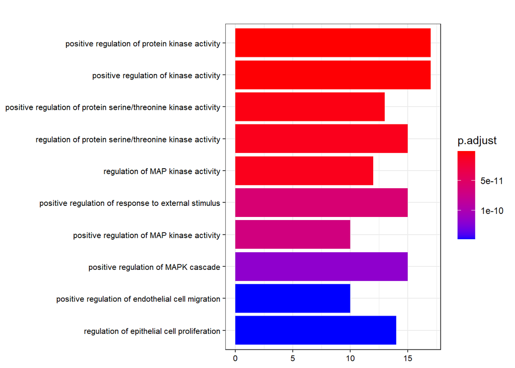

```r
ctGO_ana11 <-  enrichGO(gene =  toupper(df_clonea$Ligand),
                        OrgDb = org.Hs.eg.db,
                        keyType = "SYMBOL",
                        ont = "BP",
                        pAdjustMethod = "BH",
                        readable = TRUE)


barplot(ctGO_ana11 ,showCategory=10,font.size = 8,label_format = 50)
```

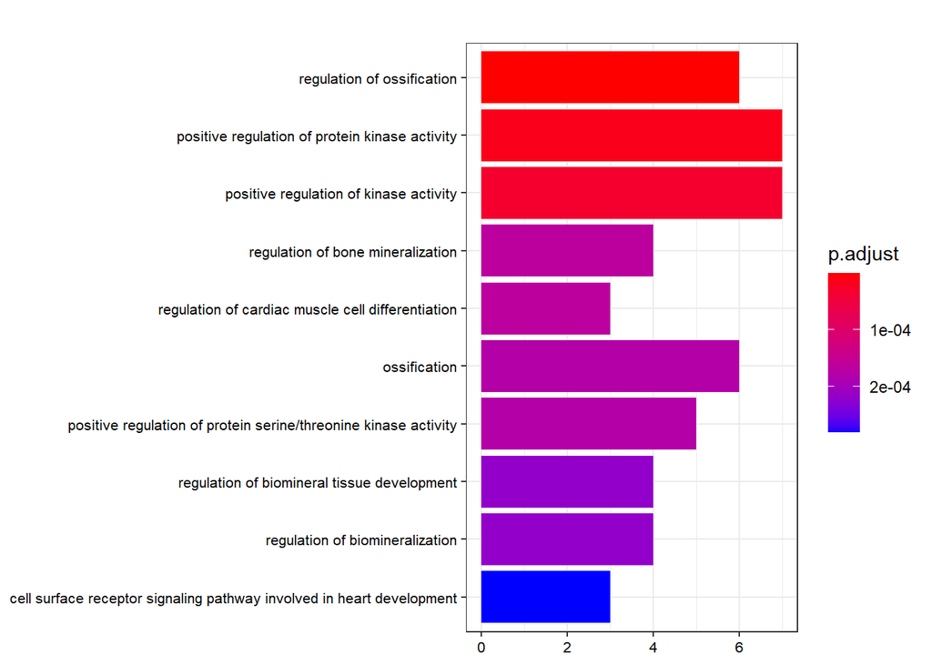

```r
ctGO_ana12 <-  enrichGO(gene =  toupper(df_cloneb$Ligand),
                        OrgDb = org.Hs.eg.db,
                        keyType = "SYMBOL",
                        ont = "BP",
                        pAdjustMethod = "BH",
                        readable = TRUE)


barplot(ctGO_ana12 ,showCategory=10,font.size = 8,label_format = 50)
```